# Kapitel 12 Sömn

## 12.1 Inledning

Epidemiologi

## 12.2 Modell för reglering av sömn och vakenhet

NREM-sömn och vakenhet bestäms av interaktion ellan flera olika system. Vakenhet stimuleras av uppåtgående monoaminerga banor från hjärnstammen, histaminerga banor i bakre hypothalamus, och kolinerga banor från tegumentet i pons och basala delar av framhjärnan. Dessa stimuleras av orexin (hypokretin) och hämmas av GABA och galanin, via neuroner med ursprung i hypothalamus vars aktivitet i sin tur regleras av “dygnsklockan” och sömn-homeostas. Kognitiv och affektiva aktivitet påverkar detta via nedåtgående banor från cortex och andra områden i diencephalon, vilka också påverkas (direkt och indirekt via thalamus) av uppåtgående banor från vakenhetssystemen. Se Fig 42-1 i ref [154].

## 12.3 Diverse

Hypnagoga hallucinationer

## 12.4 Parasomnier

## 12.5 Narkolepsi

Narkolepsi är en ovanlig sjukdom som gör att hjärnan inte kan styra sömn och vakenhet på ett normalt sätt. Det kan till exempel ge följande problem:

- Överdriven dagtrötthet: Trött och sömnig under dagen, så att det är svårt att fokusera och hålla sig vaken.
- Sömnattacker: Somnar plötsligt utan förvarning. Kan inträffa tex under samtal eller måltid. Vanligen sekunder-minuter.
- Kataplexi: Tillfällig förlust av muskelkontroll, vilket ger svaghet och kan leda till kollaps, ofta som en reaktion på känslor som skratt och ilska. Från dagligen till någon gång per år.
- Sömnparalys: Tillfällig oförmåga att röra sig eller prata i samband med att man just skall somna eller just vaknat. Vanligen sekunder-minuter.
- Överdrivet drömmande och uppvaknande under natten: Drömmarna uppträder ofta i samband med insomning (hypnagoga hallucinationer), eller uppvakning (hypnopompiska hallucinationer).

En orsak till narkolepsi tros vara brist på hypokretin (orexin), vilket kan bero på att immunystemet angiper de celler som producerar det eller blockerar de receptorer det verkar på. Utlösande faktorer tros kunna vara tex hormonförändringar (pubertet, menopaus), större psykologisk stress, infektioner. Symtomen börjar oftast i ungdomen.

Personer med narkolepsi går snabbt in i drömsömnen (REM) och den muskelsvaghet och drömmande som sker under REM kan uppträda i vaket tillstånd.

ADHD är relativt valigt vid narkolepsi (ffa typ 2)[155].

## 12.6 Anamnes och skattningsskalor

- Screening (insomni, OSAS, annat?)
- Svårighetsgrad
- Effekt av behandling

Skalor: https://insomnia.arizona.edu/measures https://www.sleepprimarycareresources.org.au/insomnia/assessment-questionnaires

“The Pittsburgh Sleep Quality Index (PSQI) is a useful tool in assessing a range of sleep health and sleep disorder symptoms”

Bedömning av sömn En forskningsöversikt om bedömningsinstrument för barn och vuxna med funktionsnedsättning: https://vardgivare.skane.se/siteassets/1.-vardriktlinjer/habilitering/fou-rapporter/2018/fourapport-2018nr2.pdf

ISI verkar enkel, kan användas för screening av insomni, och uppföljning av behandlingseffekt.

ESS Epworth, för dagtrötthet

Wisconsin verkar ha screening/anamnesfrågor för olika tillstånd.

### 12.6.1 Anamnestiska frågor

- Tupplurar under dagen?
- Dagtrötthet?
- Screening RLS: “När du försöker slappna av på kvällen eller sova på natten, har du någon gång en obehaglig, rastlös känsla i benen som lättar när du rör på dem eller går?”
- Fråga om energinivå på morgonen kan screena för föredragen dygnsrytm.
- Screening för sömnapné.
- Skiftarbete?

I [148] diskuteras en del screeningfrmulär och anamnestiska frågor.

Pittsburgh Sleep Quality Index

### 12.6.2 Prospektiv sömndagbok

[Formulär prospektiv sömndagbok](https://viss.nu/download/18.7f0158e4176840aa3316bdd9/1609159272664/somndagbok.pdf): Liknar SASS

### 12.6.3 ISI, retrospektiv symtomskattning svårighetsgrad

https://viss.nu/download/18.7353d1b51757f917add379db/1610097077243/ISI_svensk_version_2017.pdf

En kortare tre-frågorsversion finns

### 12.6.4 SASS, retrospektiv sömndagbok

SASS är en retrospektiv sömndagbok. SASS-Y delar upp samma frågor i veckodag respektive helg[156]. Följande frågor (fri översättning) ingår (tiderna är “i medeltal”):

1. När lade du dig?
2. När försökte du somna?
3. Hur länge tog det att somna?
4. Hur många gånger vaknade du (borträknat sista gången)?
5. Hur långa var dessa uppvaknanden?
6. Vilken tid var ditt sista uppvaknande?
7. När klev du upp?
8. Hur bra var din sömn? 1= mycket dåligt, 2= ganska dåligt, 3= varken bra eller dåligt, 4= ganska bra, 5= mycket bra.
9. Hyr länge har du sovit så här? År, månader, veckor.

Validity of two retrospective questionnaire versions of the Consensus Sleep Diary: the whole week and split week Self-Assessment of Sleep Surveys[156]. Finns som app?

Carney CE; Buysse DJ; Ancoli-Israel S; Edinger JD; Krystal AD; Lichstein KL; Morin CM. The consensus sleep diary: standardizing prospective sleep self-monitoring. SLEEP 2012;35(2):287-302.

## 12.7 Sömnhygien

[Sömndagbok](https://kunskapsstodforvardgivare.se/download/18.26e8250017c6f95090f8fa4/1634146276938/Soemndagbok20150316.pdf)

[Sömnhygieniska råd](https://kunskapsstodforvardgivare.se/download/18.26e8250017c6f95090f8fa6/1634146336170/Somnhygieniska-rad.pdf)

## 12.8 Läkemedelsbehandling

> It is prudent to educate patients about, and prescribe, approaches that may have the least impact on daytime function. […] While drug half-lives and clinical trials of some agents suggest that they may target initial, middle, or late sleep impairments, it is the first author’s experience that the duration and quality of sedation effect among these agents varies significantly from patient to patient[148].

> Opinion statements [53] have suggested that melatonin may be favorable as a first choice supplement for shifting sleep time, using lower doses 4–6 h before bedtime to establish biological evening, and/or higher doses before bedtime for sedative initiation of sleep[148].

> Interestingly, although amitriptyline is widely used for its sedative properties in neurological populations, a recent review could not find strong evidence for its impact on sleep [54]. This same review evaluated evidence for sleep benefit from other antidepressants, finding that only doxepin and trazodone had the highest scientific evidence among these agents, based on self-report evidence for sleep improvement. A recent study [55] considering effects of trazodone on cognition measures across 16 studies with at least 25 mg exposure for one week suggested mixed evidence for a dose-dependent negative effect on next-day cognition. These findings, again, emphasize the important trade-off that clinicians may face in trying to optimize sleep while supporting daytime function[148].

Clinical Practice Guideline for the Pharmacologic Treatment of Chronic Insomnia in Adults: An American Academy of Sleep Medicine Clinical Practice Guideline Sateia) [157]

Efficacy, acceptability, and tolerability of all available treatments for insomnia in the elderly: a systematic review and network meta-analysis[158].

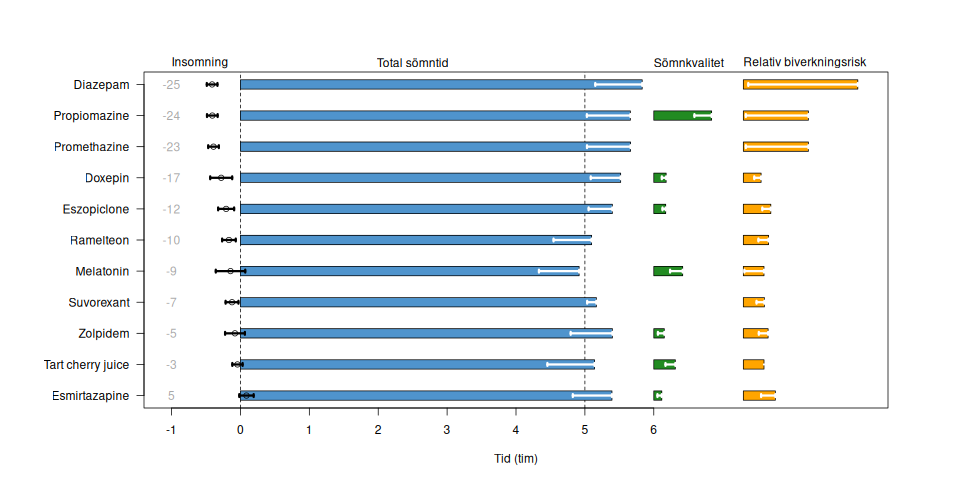

Figur 12.1: Sömnmedel, effektivitet hos äldre[158].

Comparative effects of pharmacological interventions for the acute and long-term management of insomnia disorder in adults: a systematic review and network meta-analysis[159]

How to interpret the results of a sleep study https://www.ncbi.nlm.nih.gov/pmc/articles/PMC4246141/